# Temperature Data - The Unknown Station: Blagovescensk

Aurora Massari

12/20/2019

## Introduction

We will analyze the temperature data of oldest weather station in China listed in the National Oceanic and Atmospheric Administration database to determine if there is an observed *warming trend*. We regressed temperature data by year (to see if there was a temperature trend over time). The slopes of all of our regression lines are positive (for average, minimum, and maximum temperatures), indicating a warming trend over time.

For only four out of 36 slopes are not statistically significant overall (with a p-value over 0.05), meaning those positive slopes (representing an increase in temperature over time) may be due to random chance. However, all minimum temperature slopes are statistically significant, and all but one slope (in July) for average temperature are significant as well. With maximum temperatures, three slopes were not significant (July, August, and October).

Maximum temperature is not the most ideal model to use because throughout the day, since temperature spikes may not representative of the whole day. This may also obscure averages. Minimum temperatures, especially in this relatively cold climate, are more representative of that day’s temperature since they are found between similar readings (there are no spikes).

## Obtaining the Data

The National Oceanic and Atmospheric Administration (NOAA) offers temperature data from weather stations all over the world. All of the temperature readings (and other weather-related data) is publicly available on the NOAA site. I chose to analyze the oldest Chinese weather station, Blagovescensk, which has been in operation since 1881.

## Background on the Weather Station

The Blagovescensk weather station (NOAA ID:GHCND:RSM00031510), is listed at N 50.25 E 127.5 at 130 m elevation in what appears to be a park in the Zhongyang Commercial district in Aihui, Heihe, Heilongjiang, China. It is near the bank of the Amur River just feet away from the Russian border in the northeastern part of China. On the NOAA website, the station is identified as a Chinese station, while the data in the spreadsheet appears to list Russia as the country of origin.

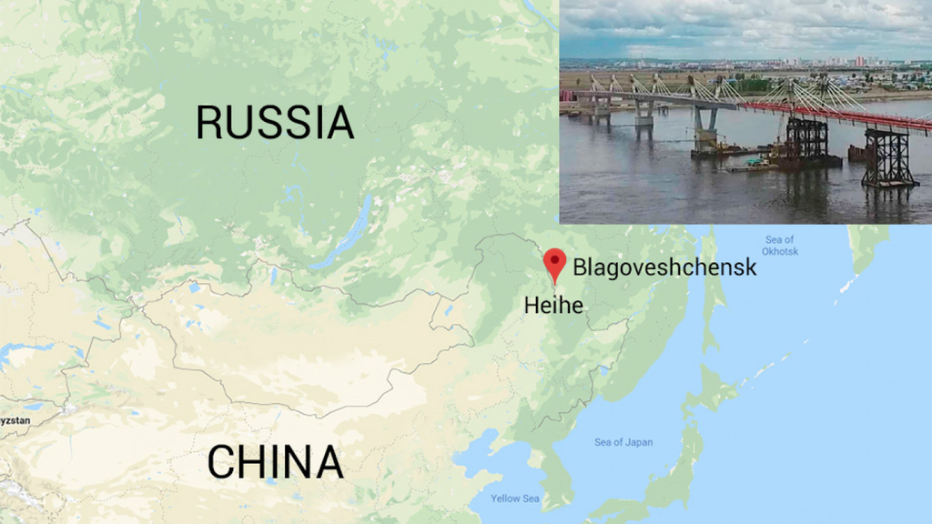

Station Location

There is next to no information on the station outside of the NOAA website, which also does not have details on the station’s history. Since the Russian city of Blagoveshchensk is right across the river from this station, it may be possible that the station was called Blagovescensk in the romanization of the city. By searching ‘“Blagovescensk” weather’, one can go to the images section and find a link to a Russian weather site. According to weather-forcast.com (a Russian weather site translated to English), the Blagoveshchensk Weather Forecast has two stations immediately near the Russian city, and both are in China. However, only one is listed on the NOAA site (Blagovescensk), and on the Russian weather site the link to the Blagovescensk station has an error message (the web page has been moved). The closest location is the Aihui (爱辉镇) station, which appears to be only a kilometer away from the Blagovescensk station and is not listed on the NOAA database.

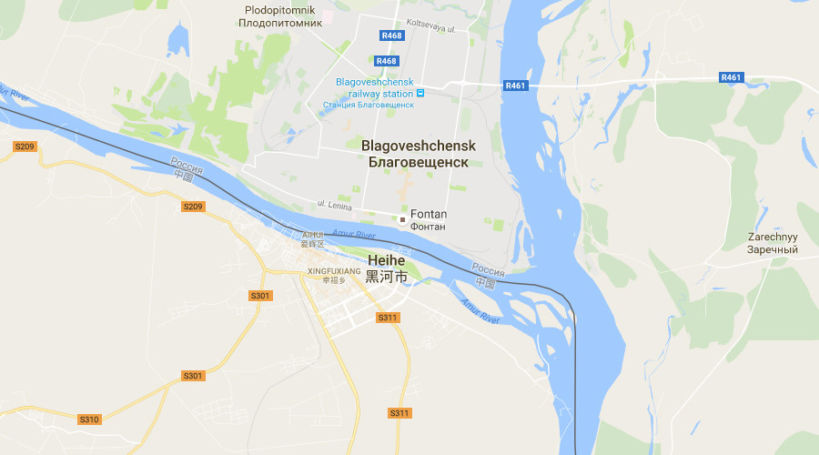

Blagovescensk Station

Since 1881, the Blagovescensk station has been recording temperature averages, later also recording minimums in 1890 and then maximums in 1914. The next weather station began recording data in 1942, sixty one years after Blagovescensk. However, there were 21 Russian weather stations that began recording data on the same day, January 1, 1881 (only one previous to this, in 1874), so it is possible that the Blagovescensk station on Chinese soil was somehow connected to these other Russian stations.

These ambiguities about the location and national identification of this particular weather station may be concerning for some people. However, this data has been cleared by the National Oceanic and Atmospheric Administration. According to NOAA, the findings are sound, at 97% overall coverage.

# Examining Outliers

To find if there are errors in the reported temperatures, we will do a simple comparison model. Temperature minimum values should be below the average and temperature maximums should be above. Outliers occur when TMAX (maximum temperature) is under TAVG (average temperature) or TMIN (minimum temperature) is over TAVG. This is potentially due to human recording error or equipment malfunction.

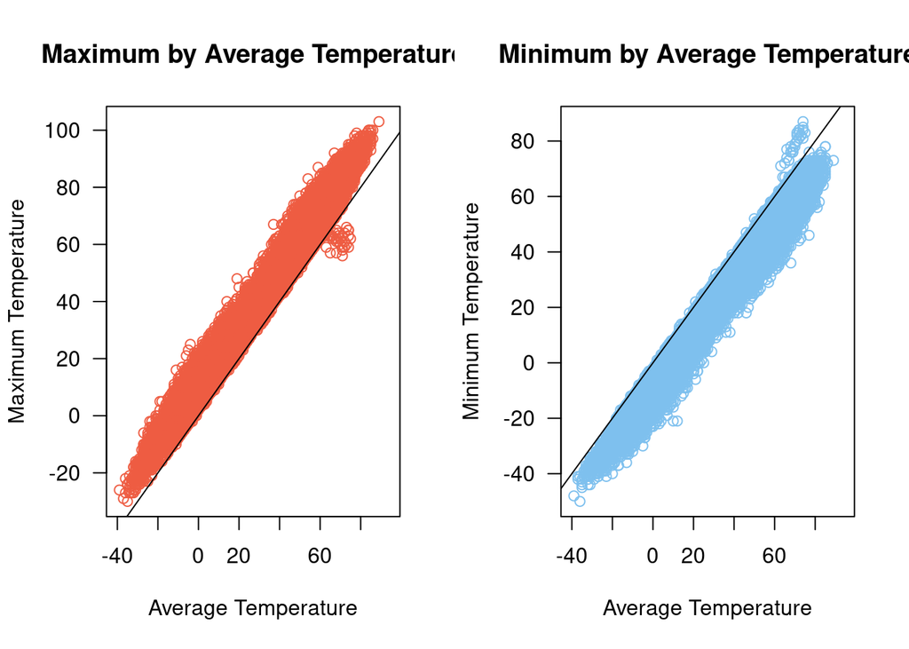

As you can see from the plots above, out of almost 50 thousand recorded temperatures, there are a few unexpected errors outside of the “probability cloud” that contains the expected values (where the maximum is above the average and the minimum is below). These 30 some mistakes are possibly due to one month when the instrument was off/not calibrated, or someone switching the TMAX. Either way, there are only about 30 unexplained observations out of almost 50,000 recorded temperatures. These will be lost in the monthly averages and likely have no effect on the results since the dataset is so large.

## Analysis of Maximum Temperature

It is unclear if maximum temperature is a singular peak, so it may not be representative of the temperature over an entire day. According to NOAA, this station has collected temperature maximums since January 1, 1914 at 99% coverage. Below, we will take a monthly average of temperature maximums since 1914 and plot the values. We will repeat this process for the temperature averages and minimums.

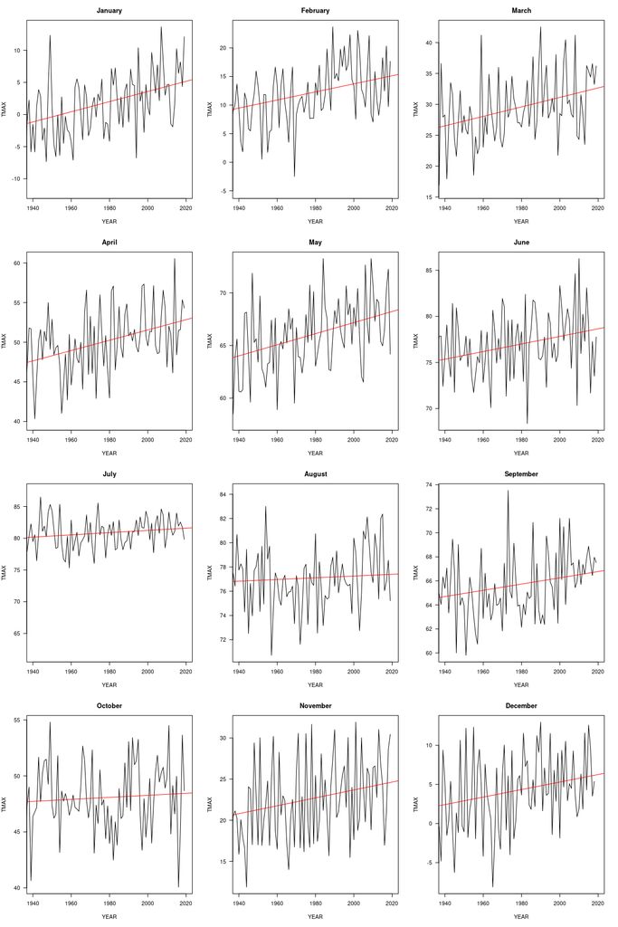

## Analysis of Minimum Temperature

Although it may be the case the minimum temperatures spike at a low point and are also not representative of daily temperatures, lower temperatures generally are representative of a more gradual decline and increase before and after the observed minimum. From NOAA, this station’s minimum temperatures have been recorded since January 1, 1890 with 89% coverage.

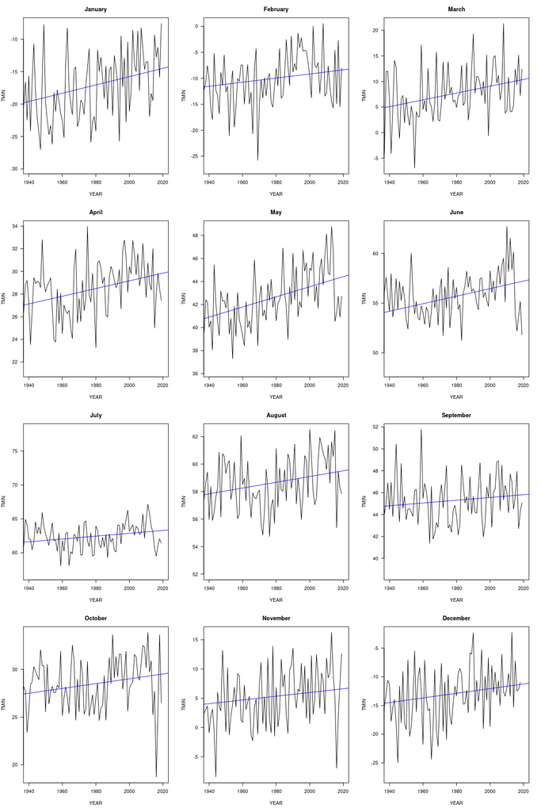

## Analysis of Average Temperature

Our station has been recording average temperatures since January 1, 1881 with 97% coverage according to NOAA. This is quite odd considering most weather stations start by recording temperature minimums and maximums before computing averages.

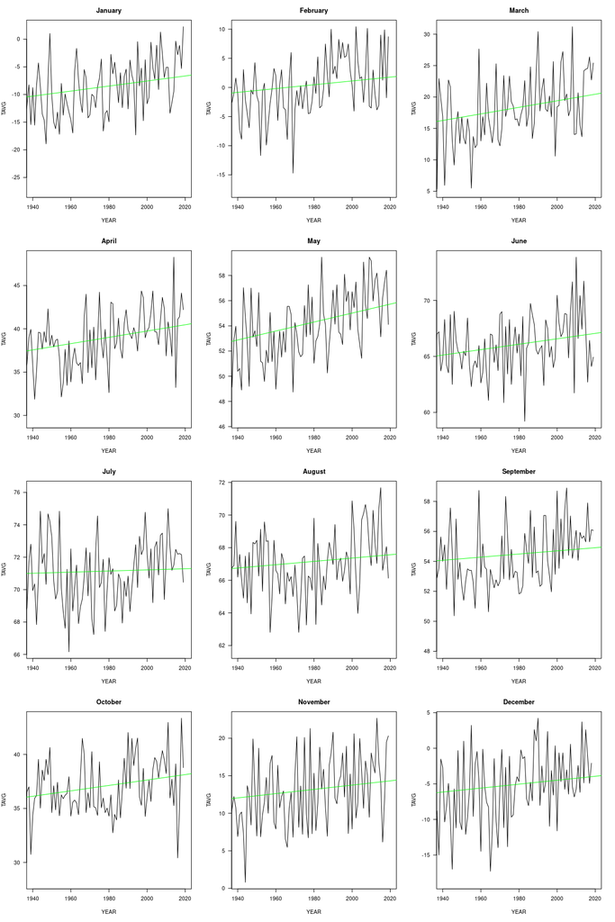

# Statistical Values Table

| Month | TAVGSlope | TAVG_P | TMAXSlope | TMAX_P | TMINSlope | TMIN_P |
| --- | --- | --- | --- | --- | --- | --- |
| January | 0.0456 | 0.0001 | **0.0791** | 0.0000 | 0.0639 | 0.0000 |
| February | 0.0327 | 0.0034 | 0.0706 | 0.0000 | 0.0396 | 0.0022 |
| **March** | **0.0522** | 0.0000 | 0.0768 | 0.0000 | **0.0667** | 0.0000 |
| **April** | 0.0363 | 0.0000 | 0.065 | 0.0000 | 0.034 | 0.0000 |
| **May** | 0.0356 | 0.0000 | 0.0527 | 0.0000 | 0.044 | 0.0000 |
| June | 0.0242 | 0.0000 | 0.0412 | 0.0001 | 0.0379 | 0.0000 |
| *July* | 0.0035 | *0.4620* | 0.0176 | *0.0816* | 0.0208 | 0.0013 |
| *August* | 0.0102 | 0.0194 | 0.0071 | *0.3857* | 0.021 | 0.0000 |
| September | 0.0105 | 0.0235 | 0.026 | 0.0024 | 0.0127 | 0.0213 |
| *October* | 0.0251 | 0.0000 | 0.0091 | *0.3488* | 0.0253 | 0.0003 |
| November | 0.0284 | 0.0028 | 0.0481 | 0.0014 | 0.0319 | 0.0067 |
| December | 0.0277 | 0.0081 | 0.048 | 0.0018 | 0.0406 | 0.0015 |

## Looking at the Three Most Significant Months

Three months had P-values lower than 0.0000: March, April, and May. We will plot these months below.

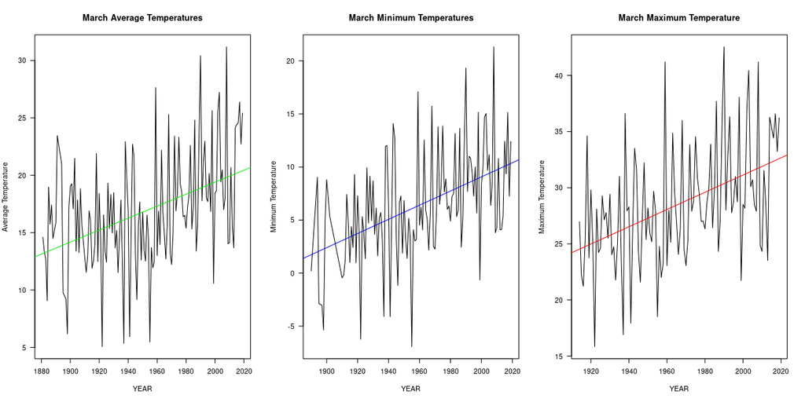

Temperature Plots for March

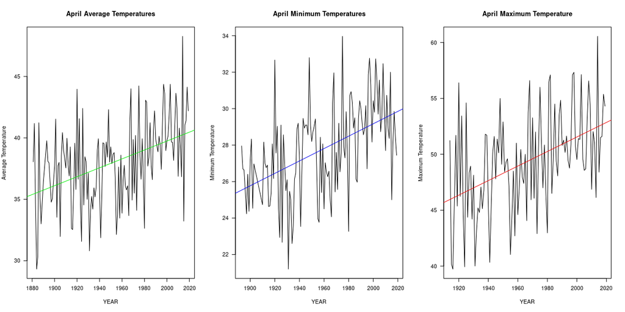

Temperature Plots for April

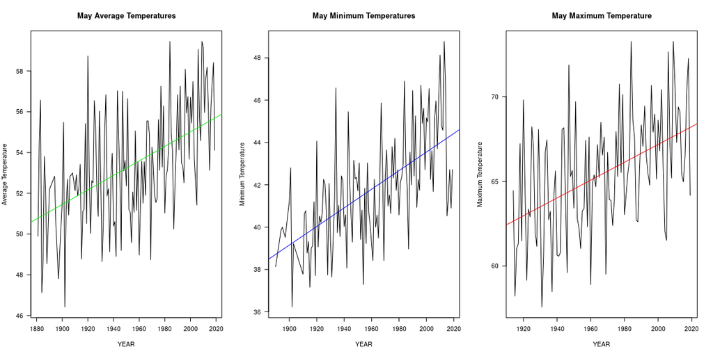

Temperature Plots for May

There is a highly significant warming trend related to time for these spring months.

## Looking at the Only Three Insignificant Months

Due to the previously mentioned temperature spikes that may skew representation of temperature data for any given day, it is unsurprising that the majority of the insignificant observations are of maximum temperatures.

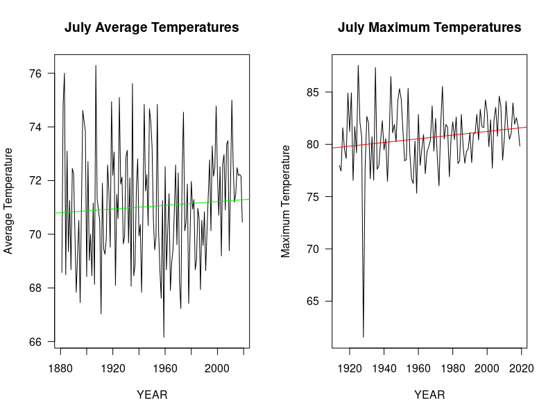

Average and Maximum Temperature Plots for July

There appear to be some extremely low maximum temperatures for the month of July. This may be the error we saw when examining the outliers. Because it occurred at during one month, it may be the case that these low values skewed the statistical analysis.

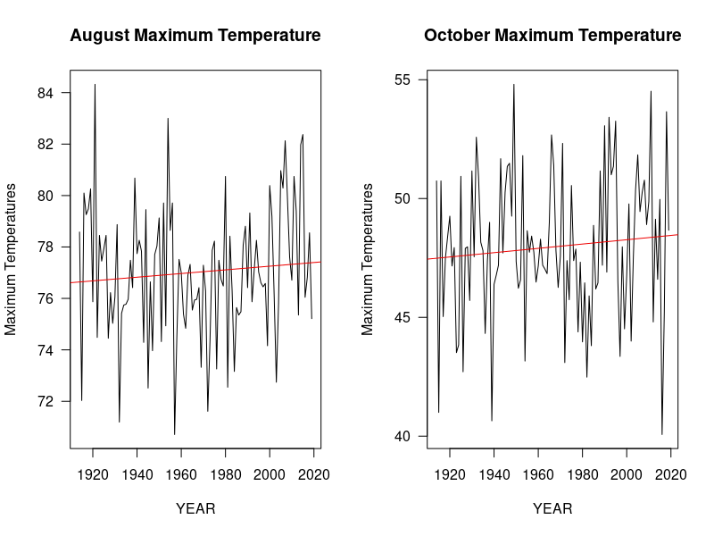

Maximum Temperature Plots for August and October

Although the slopes for both August and October are still positive, there is no significant warming trend that can be attributed to time.

# What Other Studies Found

There are several studies corroborrating a warming trend in northeastern China. The surface air temperature index has increased within the range of our station (80°E–130°E, 45°N–65°N) between 1954 adn 2010 (Zhu 2012). Such surface temperature increases may be contributed by heat urban heat islands with mass development. Further industrialization will continue to impact the heating and drying trend (Li 2009). Nearby our weather station, the Heilongjiang Highway and River Bridge encourages development in this area. Overall, there appeared to be not so much a heating trend as a “less cooling” trend. In short, there are shorter cool seasons, with autumn and winter having the strongest warming signals while summer has the weakest (Zhai 1999). These findings match our analysis of the insignificant observations in July and August. Also, our lowest p-values and highest slopes were in the winter and spring. Shorter cool seasons also makes the northeastern region of China more suitable for agriculture where it was not before (Yang 2007). There are several environmental implications of this, namely a weakening of the natural wetland ecosystem in the region. Previously undisturbed wetlands in and around Xing’an Mountain will be vulnerable, a predicted 30% decrease in the wetland ecosystem (Liu 2011). Although increased urbanization (and the warming that comes with it) may open new commercial opportunities in the agrigultural or shipping industries for northeastern China, the southern regions are experiencing increasingly dry and warm climates (Zhai 1999).

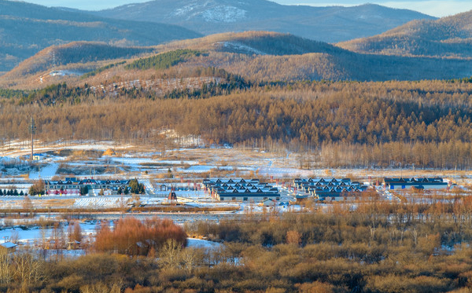

Xing’an Mountains

# Conclusions

It is true that our analysis discovered a strong warming trend with time. This does not explicitly link such a trend with increased greenhouse gasses in the atmosphere, although we assume this is the primary contributor, since over time humans have been pumping more and more greenhouse gasses into the atmosphere and disrupting Earth’s natural balance (Bennett 2019).

# Literature Cited

Bennett J. 2019. A Global Warming Primer: Answering Your Questions About the Science, the Consequences, and the Solutions. Available from: https://www.globalwarmingprimer.com/primer/ Li Q.2009. Assessment of surface air warming in northeast China, with emphasis on the impacts of urbanization. Theor & Appl. Climato. 99: 469-478.  
Liu H. 2011. Predicting the wetland distributions under climate warming in the Great Xing’an Mountains, northeastern China. Ecol Res. 26: 605–613  
Staff. 2019. Blagoveshchensk Weather Forecast. Metero365: https://www.weather-forecast.com/locations/Blagoveshchensk/forecasts/latest  
Staff. 2015. Temperature Monitoring Station: BLAGOVESHCHENSK. Berkeley Earth: http://berkeleyearth.lbl.gov/stations/169111  
Yang X. 2007. Adaptation of agriculture to warming in Northeast China. Climatic Chan. 84: 45-58.  
Zhai P. 1999. Changes of Climate Extremes in China. Climatic Chan. 42: 203-218.  
Zhu C. 2012. Recent weakening of northern East Asian summer monsoon: A possible response to global warming. Geophy. Res. Lett. 39 (9): 1-6.